# Homework 1

2024-06-06

## HA 6.2 (Version 2)

The `plastics` data set consists of the monthly sales (in thousands) of product A for a plastics manufacturer for five years.

> 1. Plot the time series of sales of product A.

To begin, we’re importing the appropriate libraries and then plotting the data.

```r
library(seasonal)
library(fpp2)
```

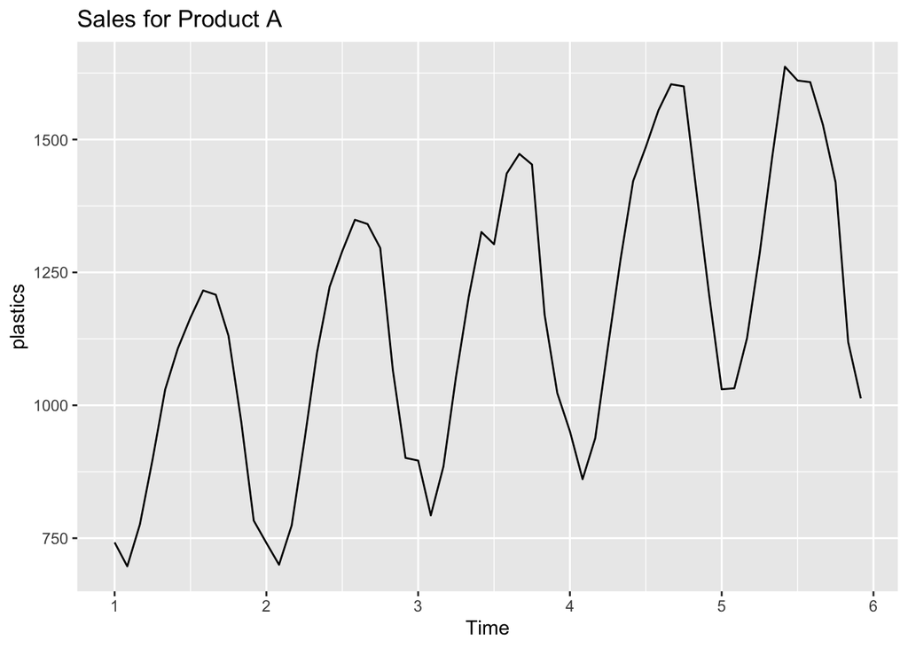

```r
autoplot(plastics) +
  ggtitle("Sales for Product A")
```

The output above is the expected graph.

> 1. Can you identify seasonal fluctuations and/or a trend-cycle?

There are definitely seasonal fluctuations - sales seems to have a cyclical pattern where it peaks around August/September and then goes back down with lows in February. There also seems to be an upwards trend where sales overall increase year over year.

> 2. Use a classical multiplicative decomposition to calculate the trend-cycle and seasonal indices.

We’re using decompose here for this problem with the multiplicative type.

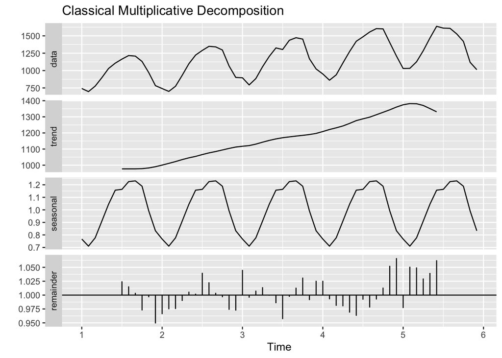

```r
decomp <- decompose(plastics, type = "multiplicative")

autoplot(decomp) +
  ggtitle("Classical Multiplicative Decomposition")
```

The output above is the expected information from the decomposition.

> 3. Do the results support the graphical interpretation from part a?

Yes, these results show the seasonal output which shows the cyclical nature of sales as well as the overall trend of it going upwards.

> 4. Compute and plot the seasonally adjusted data.

To do this, we are extracting the necessary information from the decomposition and applying that information to the plastics dataframe.

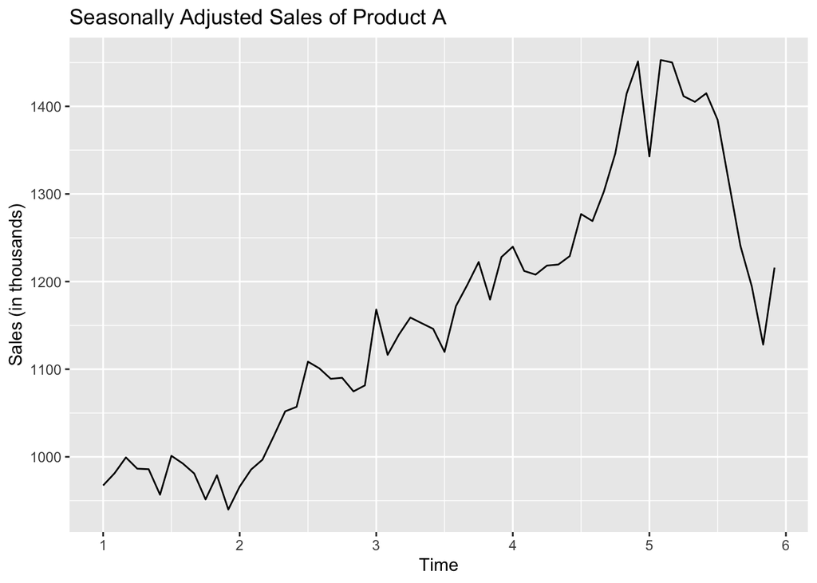

```r
trend <- decomp$trend
seasonal <- decomp$seasonal
random <- decomp$random

seasonally_adjusted <- plastics / seasonal

# Plot the seasonally adjusted data
autoplot(seasonally_adjusted) +
  ggtitle("Seasonally Adjusted Sales of Product A") +
  ylab("Sales (in thousands)") +
  xlab("Time")
```

The output above is the expected graph with applied information from the decomposition.

> Change one observation to be an outlier (e.g., add 500 to one observation), and recompute the seasonally adjusted data. What is the effect of the outlier?

The outlier we’re adding here is just modifying an existing observation by 750.

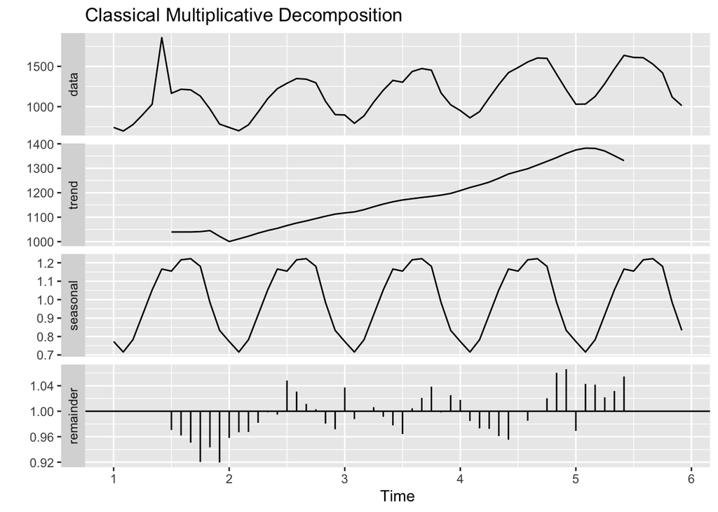

```r
# outlier: add 750 to the 25th observation
plastics_outlier <- plastics
plastics_outlier[6] <- plastics_outlier[6] + 750

decomp_outlier <- decompose(plastics_outlier, type = "multiplicative")

autoplot(decomp_outlier) +
  ggtitle("Classical Multiplicative Decomposition")
```

The effect of the outlier is the trend seems to go down before going up, however seasonality remains the same so that was unchanged.

> Does it make any difference if the outlier is near the end rather than in the middle of the time series?

The location difference would change how the trend comes out, however unless there are multiple outliers scattered across the years, the seasonality of the data won’t change.

## HA 7.2 (Version 2)

Write your own function to implement simple exponential smoothing. The function should take arguments `y` (the time series), `alpha` (the smoothing parameter $\alpha$) and `level` (the initial level$\ell_0$ ). It should return the forecast of the next observation in the series. Does it give the same forecast as `ses()`?

```r
library(forecast)

# define the simple exponential smoothing function
simple_exponential_smoothing <- function(y, alpha, level) {
  l <- level  # initial level
  for (t in seq_along(y)) {
    l <- alpha * y[t] + (1 - alpha) * l
  }
  # the forecast for the next observation is the last level value
  return(l)
}

# example
y <- c(3, 10, 12, 13, 12, 10, 12)
alpha <- 0.2
initial_level <- y[1]

forecast_custom <- simple_exponential_smoothing(y, alpha, initial_level)
cat("The forecast for the next observation using custom function is:", forecast_custom, "\n")
```

```
## The forecast for the next observation using custom function is: 9.292032
```

```r
# using the forecast package's ses() function
ses_model <- ses(y, alpha = alpha, initial = "simple", h = 1)
forecast_ses <- ses_model$mean
cat("The forecast for the next observation using forecast::ses function is:", forecast_ses, "\n")
```

```
## The forecast for the next observation using forecast::ses function is: 9.292032
```

This does return the same result!

## HA 8.6 (Version 2)

> Use R to simulate and plot some data from simple ARIMA models.

Use the following R code to generate data from an AR(1) model with $\theta_1 = 0.6$ and $\sigma^2 = 1$. The process starts with $y_1=0$

```r
y <- ts(numeric(100))
e <- rnorm(100)
for(i in 2:100)
  y[i] <- 0.6*y[i-1] + e[i]
```

> Produce a time plot for the series. How does the plot change as you change $\varphi_1$?

We will use ggplot to plot this.

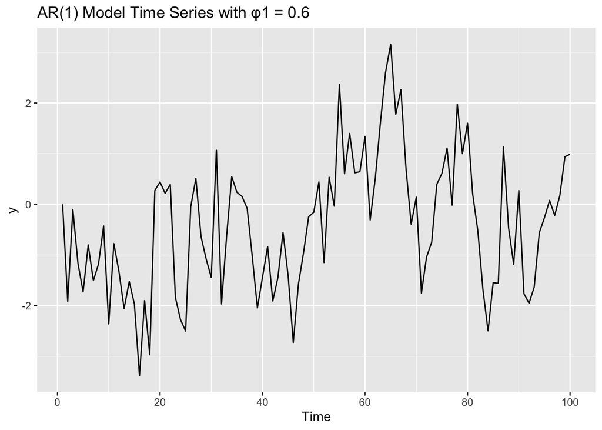

```r
library(ggplot2)
autoplot(y) + ggtitle("AR(1) Model Time Series with φ1 = 0.6") + ylab("y") + xlab("Time")
```

Now, we will modify $\varphi_1$ to be 0.2, 0.6, and 0.9.

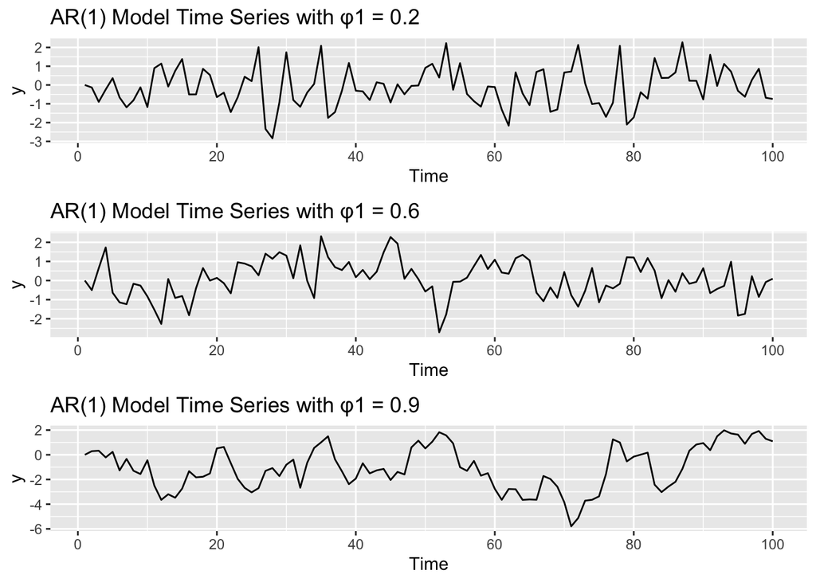

```r
phi_values <- c(0.2, 0.6, 0.9)
plots <- lapply(phi_values, function(phi1) {
  y <- ts(numeric(100))
  e <- rnorm(100)
  for(i in 2:100) {
    y[i] <- phi1 * y[i-1] + e[i]
  }
  autoplot(y) + ggtitle(paste("AR(1) Model Time Series with φ1 =", phi1)) + ylab("y") + xlab("Time")
})

# display differences
library(gridExtra)
do.call(grid.arrange, c(plots, ncol = 1))
```

We can see that with the different values, as it got higher, the less messy the data got (less peaks/valleys). You could say that as it increases, the series becomes more persistent with deviations lasting longer while lower values has it behave similar to white noise.

> Write your own code to generate data from an MA(1) model with $\theta_1=0.6$ and $\sigma^2=1$

```r
theta1 <- 0.6
y <- ts(numeric(100))
e <- rnorm(100)
for(i in 2:100) {
  y[i] <- e[i] + theta1 * e[i-1]
}
```

> Produce a time plot for the series. How does the plot change as you change $\theta_1$?

First, we will produce a plot.

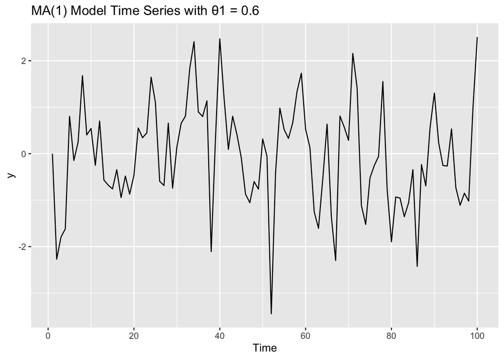

```r
autoplot(y) + ggtitle("MA(1) Model Time Series with θ1 = 0.6") + ylab("y") + xlab("Time")
```

Now we will modify $\theta_1$ to be 0.2, 0.6, and 0.9.

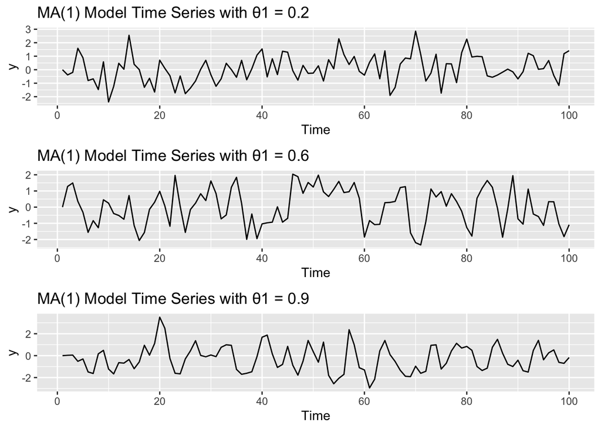

```r
theta_values <- c(0.2, 0.6, 0.9)
plots <- lapply(theta_values, function(theta1) {
  y <- ts(numeric(100))
  e <- rnorm(100)
  for(i in 2:100) {
    y[i] <- e[i] + theta1 * e[i-1]
  }
  autoplot(y) + ggtitle(paste("MA(1) Model Time Series with θ1 =", theta1)) + ylab("y") + xlab("Time")
})

# display plots
do.call(grid.arrange, c(plots, ncol = 1))
```

Similar to the previous alteration, as we make the variable larger, the series becomes more smoothed while the lower it is, the more random it is.

> Generate data from an ARMA(1,1) model with $\varphi_1=0.6$, $\theta_1=0.6$ and $\sigma^2=1$.

We will generate the data with the given variables.

```r
phi1 <- 0.6
theta1 <- 0.6
y_arma11 <- ts(numeric(100))
e <- rnorm(100)
for(i in 2:100) {
  y_arma11[i] <- phi1 * y_arma11[i-1] + e[i] + theta1 * e[i-1]
}
```

> Generate data from an AR(2) model with $\varphi_1=−0.8$, $\theta_2=0.3$, and $\sigma^2=1$. (Note that these parameters will give a non-stationary series.)

We will generate the data with the given variables.

```r
phi1 <- -0.8
theta2 <- 0.3
y_ar2 <- ts(numeric(100))
e <- rnorm(100)
for(i in 3:100) {
  y_ar2[i] <- phi1 * y_ar2[i-1] + theta2 * y_ar2[i-2] + e[i]
}
```

> Graph the latter two series and compare them.

Now, we will plot the data.

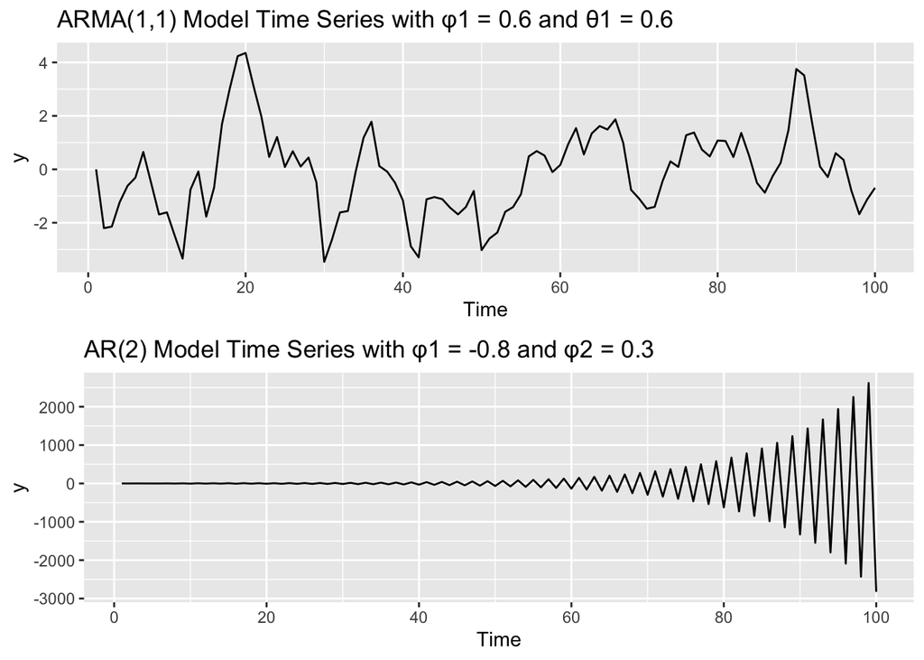

```r
p1 <- autoplot(y_arma11) + ggtitle("ARMA(1,1) Model Time Series with φ1 = 0.6 and θ1 = 0.6") + ylab("y") + xlab("Time")
p2 <- autoplot(y_ar2) + ggtitle("AR(2) Model Time Series with φ1 = -0.8 and φ2 = 0.3") + ylab("y") + xlab("Time")

library(gridExtra)
grid.arrange(p1, p2, ncol = 1)
```